# Analyzing doubly-truncated mortality data using the gompertztrunc package

Casey Breen (caseybreen@berkeley.edu)

Maria Osborne (mariaosborne@berkeley.edu)

## Summary

This vignette gives an overview of the `gompertztrunc` package and presents three case-studies illustrating the package’s functionality. The goal of this vignette is to give users a high-level overview of using the `gompertztrunc` package for mortality estimation including the use of weights, the specification and visualization of models, and limitations of this approach.

## Background

Researchers increasingly have access to administrative mortality records that only include those who have died for a limited observation window without information on survivors. The double truncation and absence of denominators precludes the use of conventional tools of survival analysis. The `gompertztrunc` package includes tools for mortality estimation of doubly-truncated data sets without population denominators.

## Summary of Parametric Gompertz Approach

This method assumes mortality follows a parametric Gompertz proportional-hazard model and uses maximum likelihood methods to estimate the parameters of this mortality distribution. Specifically, the hazard for individual $i$ at age $x$ given parameters $\beta$ is given by

$$h_i(x | \beta) = a_0 e^{b_0 x} e^{\beta
Z_i}$$
where

- $h(x)$ is the hazard at age $x$
- $a_0$ is some baseline level of mortality
- $b_0$ gives rate of increase of mortality
- $Z_i$ are the covariates for person $i$ (e.g., years of education, place of birth)
- $\beta$ is the set of parameters

The model will estimate the values of $\widehat{a}$, $\widehat{b}$, and $\widehat{\beta}$.

The main function in the package is the `gompertztrunc::gompertz_mle()` function, which takes the following main arguments:

- `formula`: model formula (for example, death_age ~ educ_yrs + homeownership)
- `left_trunc`: year of lower truncation
- `right_trunc`: year of upper truncation
- `data`: data frame with age of death variable and covariates
- `byear`: year of birth variable
- `dyear`: year of death variable
- `lower_age_bound`: lowest age at death to include (optional)
- `upper_age_bound`: highest age at death to include (optional)
- `weights`: an optional vector of person-level weights
- `start`: an optional vector of starting values for the optimizer
- `maxiter`: maximum number of iteration for optim function

## Setup

```r
## library packages
library(gompertztrunc)         ## calculate mortality differentials under double-truncation
library(tidyverse)             ## data manipulation and visualization
library(data.table)            ## fast data manipulation
library(cowplot)               ## publication-ready themes for ggplot
library(socviz)                ## helper functions for data visualization (Kieran Healy)
library(broom)                 ## "tidy" model output


## load data
sim_data <- sim_data             ## simulated
bunmd_demo <- bunmd_demo         ## real
numident_demo <- gompertztrunc::numident_demo   ## real
```

## Case Study I: Simulated Data

In our first case study, we use simulated (fake) data included in the gompertztrunc package. Because we simulated the data, we know the true coefficient values (we also know that the mortality follows a Gompertz distribution and our proportional hazards assumption holds).

```r
## Look at simulated data
head(sim_data)
```

```
##    aod byear dyear       temp sex isSouth
## 1:  87  1810  1897 -4.6198501   1       0
## 2:  78  1810  1888 -0.8841613   1       0
## 3:  79  1810  1890  0.7566703   1       0
## 4:  85  1810  1895 -0.6728037   1       0
## 5:  85  1810  1896 -3.8537981   1       0
## 6:  81  1810  1891 -1.2885393   1       0
```

```r
## What years do we have mortality coverage?
sim_data %>%
  summarize(min(dyear), max(dyear))
```

```
##   min(dyear) max(dyear)
## 1       1888       1905
```

Now let’s try running `gompertz_mle()` function on the simulated data:

```r
## run gompertz_mle function
## returns a list
simulated_example <- gompertz_mle(formula = aod ~ temp + as.factor(sex) + as.factor(isSouth),
                                                 left_trunc = 1888,
                                                 right_trunc = 1905,
                                                 data = sim_data)
```

The `gompertz_mle()` function returns a list which contains three elements:

1. The initial starting parameters for the MLE routine. Unless specified by the user, these are found using OLS regression on age at death.
2. The full `optim` object, which gives details of the optimization routine (e.g., whether the model converged).
3. A data.frame of containing results: the estimated Gompertz parameters, coefficients, and hazards ratios with 95% confidence intervals.

We recommend always checking the full `optim` object to make sure the model has converged.

```r
## 1. starting value for coefficients (from linear regression)
simulated_example$starting_values
```

```
##         log.b.start            b0.start                temp     as.factor(sex)1
##         -2.30258509         -9.96897213          0.07505734         -0.18001387
## as.factor(isSouth)1
##          0.22607193
```

```r
## 2. optim fit object
simulated_example$optim_fit
```

```
## $par
##         log.b.start            b0.start                temp     as.factor(sex)1
##          -2.2745186          -9.4083999           0.2068584          -0.5300299
## as.factor(isSouth)1
##           0.5983461
##
## $value
## [1] 17549.16
##
## $counts
## function gradient
##      886       NA
##
## $convergence
## [1] 0
##
## $message
## NULL
##
## $hessian
##                     log.b.start  b0.start       temp as.factor(sex)1
## log.b.start           283845.66 35822.202 -36549.785       20205.368
## b0.start               35822.20  4536.154  -4552.676        2553.982
## temp                  -36549.79 -4552.676  32378.684       -1569.926
## as.factor(sex)1        20205.37  2553.982  -1569.926        2553.949
## as.factor(isSouth)1    14017.01  1783.017  -3199.463        1109.978
##                     as.factor(isSouth)1
## log.b.start                   14017.009
## b0.start                       1783.017
## temp                          -3199.463
## as.factor(sex)1                1109.978
## as.factor(isSouth)1            1783.000
```

```r
## 2. check model convergence (0 == convergence)
simulated_example$optim_fit$convergence
```

```
## [1] 0
```

```r
## 3. Look at model results
simulated_example$results
```

```
## # A tibble: 5 × 7
##   parameter             coef coef_lower coef_upper     hr hr_lower hr_upper
##   <chr>                <dbl>      <dbl>      <dbl>  <dbl>    <dbl>    <dbl>
## 1 gompertz_b           0.103     0.0964      0.110 NA       NA       NA
## 2 gompertz_mode       69.4      64.4        74.3   NA       NA       NA
## 3 temp                 0.207     0.194       0.219  1.23     1.21     1.25
## 4 as.factor(sex)1     -0.530    -0.590      -0.470  0.589    0.554    0.625
## 5 as.factor(isSouth)1  0.598     0.536       0.661  1.82     1.71     1.94
```

The first row gives the estimated Gompertz $b$ parameter, and the second row gives the Gompertz mode. The next three rows show each covariate’s estimated coefficient and associated hazard ratio. A hazard ratio compares the ratio of the hazard rate in a population strata (e.g., treated group) to a population baseline (i.e., control group). A hazard ratio above 1 suggests a higher risk at all ages and a hazard ratio below 1 suggests a smaller mortality risk at all ages (assuming proportional hazards).

Let’s compare our estimated values to true value. We can only do this because this is simulated (fake) data.

```r
## true coefficient values (we know because we simulated them)
mycoefs <- c("temp" = +.2, "sex" = -.5, "isSouth" = +.6)

## compare
simulated_example$results %>%
  filter(!stringr::str_detect(parameter, "gompertz")) %>%
  mutate(true_coef = mycoefs) %>%
  select(parameter, coef, coef_lower, coef_upper, true_coef)
```

```
## # A tibble: 3 × 5
##   parameter             coef coef_lower coef_upper true_coef
##   <chr>                <dbl>      <dbl>      <dbl>     <dbl>
## 1 temp                 0.207      0.194      0.219       0.2
## 2 as.factor(sex)1     -0.530     -0.590     -0.470      -0.5
## 3 as.factor(isSouth)1  0.598      0.536      0.661       0.6
```

While investigators will likely report hazard ratios, translating hazard ratios into differences in life expectancy may help facilitate interpretation and comparison to other studies. We have included this functionality in the gompertztrunc package with the `convert_hazards_to_ex()` function:

```r
## translate hazard rates to difference in e65
convert_hazards_to_ex(simulated_example$results, age = 65, use_model_estimates = T) %>%
  select(parameter, hr, hr_lower, hr_upper, e65, e65_lower, e65_upper)
```

```
## # A tibble: 3 × 7
##   parameter              hr hr_lower hr_upper    e65 e65_lower e65_upper
##   <chr>               <dbl>    <dbl>    <dbl>  <dbl>     <dbl>     <dbl>
## 1 temp                1.23     1.21     1.25  -0.966     -1.02    -0.910
## 2 as.factor(sex)1     0.589    0.554    0.625  2.84       2.49     3.20
## 3 as.factor(isSouth)1 1.82     1.71     1.94  -2.57      -2.80    -2.33
```

## Case Study II: Real-World Example with BUNMD Data

In our second case study, we look at the mortality advantage for the foreign-born. We use a demo dataset from the Berkeley Unified Numident Mortality Database (BUNMD) and compare our results to results from OLS regression (a method which is biased in the presence of truncation).

```r
## look at data
head(bunmd_demo)
```

```
## # A tibble: 6 × 6
##         ssn bpl_string death_age byear dyear age_first_application
##       <int> <fct>          <int> <int> <int>                 <int>
## 1 267729143 Cuba              89  1912  2002                    49
## 2 266172087 Cuba              80  1911  1991                    57
## 3 590072321 Cuba              92  1911  2004                    69
## 4 265064566 Cuba              76  1913  1989                    53
## 5 265877097 Cuba              86  1908  1995                    70
## 6 264745485 Cuba              87  1915  2003                    46
```

```r
## how many people per country?
bunmd_demo %>%
  count(bpl_string)
```

```
## # A tibble: 6 × 2
##   bpl_string            n
##   <fct>             <int>
## 1 Native Born White 20000
## 2 Cuba              13194
## 3 England            7561
## 4 Italy             15306
## 5 Mexico            13755
## 6 Poland            11186
```

First, let’s look at the distribution of deaths by country:

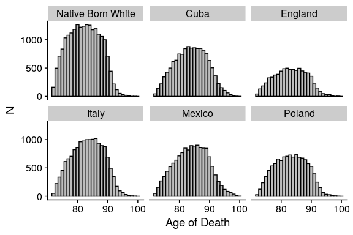

```r
## distribution of deaths?
ggplot(data = bunmd_demo) +
  geom_histogram(aes(x = death_age),
                 fill = "grey",
                 color = "black",
                 binwidth = 1) +
  cowplot::theme_cowplot() +
  labs(x = "Age of Death",
       y = "N") +
  facet_wrap(~bpl_string)
```

### Linear regression approach

Let’s look at the association between country of origin and longevity. First, we’ll try using a biased approach (OLS regression on age of death).

```r
## run linear model
lm_bpl <- lm(death_age ~ bpl_string + as.factor(byear), data = bunmd_demo)

## extract coefficients from model
lm_bpl_tidy <- tidy(lm_bpl) %>%
  filter(str_detect(term, "bpl_string")) %>%
  mutate(term = prefix_strip(term, "bpl_string"))

## rename variables
lm_bpl_tidy <- lm_bpl_tidy %>%
  mutate(
    e65 = estimate,
    e65_lower = estimate - 1.96 * std.error,
    e65_upper = estimate + 1.96 * std.error
  ) %>%
  rename(country = term) %>%
  mutate(method = "Regression on Age of Death")
```

Now we’ll perform estimation with the `gompertztrunc` package:

```r
## run gompertztrunc
## set truncation bounds to 1988-2005 because we are using BUNMD
gompertz_mle_results <- gompertz_mle(formula = death_age ~ bpl_string,
                                    left_trunc = 1988,
                                    right_trunc = 2005,
                                    data = bunmd_demo)

## convert to e65
## use model estimates — but can also set other defaults for Gompertz M and b.
mle_results <- convert_hazards_to_ex(gompertz_mle_results$results, use_model_estimates = T)

## tidy up results
mle_results <- mle_results %>%
  rename(country = parameter) %>%
  filter(str_detect(country, "bpl_string")) %>%
  mutate(country = prefix_strip(country, "bpl_string")) %>%
  mutate(method = "Gompertz Parametric Estimate")

## look at results
mle_results
```

```
## # A tibble: 5 × 11
##   country   coef coef_lower coef_u…¹    hr hr_lo…² hr_up…³   e65 e65_l…⁴ e65_u…⁵
##   <chr>    <dbl>      <dbl>    <dbl> <dbl>   <dbl>   <dbl> <dbl>   <dbl>   <dbl>
## 1 Cuba    -0.229     -0.270  -0.188  0.796   0.764   0.829 1.70    1.39     2.01
## 2 England -0.130     -0.179  -0.0815 0.878   0.836   0.922 0.960   0.597    1.33
## 3 Italy   -0.178     -0.217  -0.138  0.837   0.805   0.871 1.31    1.02     1.61
## 4 Mexico  -0.369     -0.412  -0.325  0.692   0.662   0.723 2.77    2.44     3.11
## 5 Poland  -0.185     -0.229  -0.141  0.831   0.795   0.869 1.37    1.04     1.70
## # … with 1 more variable: method <chr>, and abbreviated variable names
## #   ¹coef_upper, ²hr_lower, ³hr_upper, ⁴e65_lower, ⁵e65_upper
```

### Visualize Results

Here, we compare our estimates from ‘unbiased’ Gompertz MLE method and our old ‘biased’ method, OLS regression on age of death. We can see that the OLS results are attenuated towards 0 due to truncation.

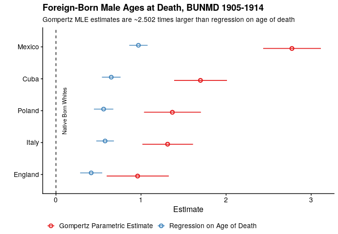

```r
## combine results from both models
bpl_results <- lm_bpl_tidy %>%
  bind_rows(mle_results)

## calculate adjustment factor (i.e., how much bigger are Gompertz MLE results)
adjustment_factor <- bpl_results %>%
  select(country, method, e65) %>%
  pivot_wider(names_from = method, values_from = e65) %>%
  mutate(adjustment_factor = `Gompertz Parametric Estimate` / `Regression on Age of Death`) %>%
  summarize(adjustment_factor_mean = round(mean(adjustment_factor), 3)) %>%
  as.vector()

## plot results
bpl_results %>%
  bind_rows(mle_results) %>%
  ggplot(aes(y = reorder(country, e65), x = e65, xmin = e65_lower, xmax = e65_upper, color = method)) +
  geom_pointrange(position = position_dodge(width = 0.2), shape = 1) +
  cowplot::theme_cowplot(font_size = 12) +
  geom_vline(xintercept = 0, linetype = "dashed") +
  theme(legend.position = "bottom", legend.title = element_blank()) +
  labs(
    x = "Estimate",
    title = "Foreign-Born Male Ages at Death, BUNMD 1905-1914",
    y = "",
    subtitle = paste0("Gompertz MLE estimates are ~", adjustment_factor, " times larger than regression on age of death")
  ) +
  scale_color_brewer(palette = "Set1") +
  annotate("text", label = "Native Born Whites", x = 0.1, y = 3, angle = 90, size = 3, color = "black")
```

### Diagnostic Plots

The `gompertztrunc` package offers two different graphical methods for assessing model fit. Please note that these diagnostic plots are only designed to assess the effect of a single categorical variable within a single cohort.

To illustrate, we will visually assess how well the modeled Gompertz distribution of mortality by country of origin fits empirical data. We will limit the model to the birth cohort of 1915. Additionally, to reduce the number of plots generated, we will only consider men born in the US and Mexico.

```r
## create the dataset
bunmd_1915_cohort <- bunmd_demo %>%
  filter(byear == 1915, death_age >= 65) %>%
  filter(bpl_string %in% c("Native Born White", "Mexico"))

## run gompertz_mle()
bpl_results_1915_cohort <- gompertz_mle(formula = death_age ~ bpl_string,
                                   data = bunmd_1915_cohort,
                                   left_trunc = 1988,
                                   right_trunc = 2005)

## look at results
bpl_results_1915_cohort$results
```

```
## # A tibble: 3 × 7
##   parameter           coef coef_lower coef_upper     hr hr_lower hr_upper
##   <chr>              <dbl>      <dbl>      <dbl>  <dbl>    <dbl>    <dbl>
## 1 gompertz_b        0.0831     0.0715     0.0965 NA       NA       NA
## 2 gompertz_mode    81.1       70.2       91.9    NA       NA       NA
## 3 bpl_stringMexico -0.419     -0.575     -0.263   0.658    0.563    0.769
```

The first diagnostic graph, `diagnostic_plot()`, compares the empirical distribution of deaths to the modeled distribution.

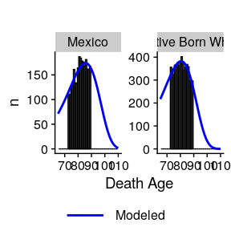

```r
diagnostic_plot(object = bpl_results_1915_cohort, data = bunmd_1915_cohort,
                covar = "bpl_string", death_var = "death_age")
```

Additionally, we can compare modeled and “observed” hazards with the `diagnostic_plot_hazard()` function. This function can be used both to assess model fit and to check the proportional hazards assumption of the model. However, these plots should be interpreted with some caution: because there are no population denominators, true hazard rates are unknown. Since we do not know the actual number of survivors to the observable death window, this value is inferred from the *modeled* Gompertz distribution. Refer to the `diagnostic_plot_hazard()` documentation for more details.

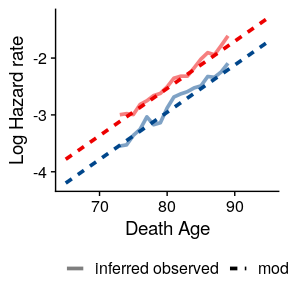

```r
diagnostic_plot_hazard(object = bpl_results_1915_cohort, data = bunmd_1915_cohort,
                covar = "bpl_string", death_var = "death_age", xlim=c(65,95))
```

## Case Study III: Education and longevity analysis with person-weights

In our third case study, we look at the association between education and longevity. We’ll use a pre-linked “demo” version of the CenSoc-Numident file, which contains 63 thousand mortality records and 20 mortality covariates from the 1940 census (~1% of the complete CenSoc-Numident dataset). We’ll also incorporate person-level weights into our analysis.

### Person-weights

The `gompertz_mle()` function can incorporate person-level weights via the `weights` argument. These person weights can help adjust for differential representation; the weight assigned to each person is proportional to the estimated number of persons in the target population that person represents. The vector of supplied weights must be long as the data, and all weights must be positive.

```r
## load in file
numident_demo <- numident_demo

## recode categorical education variable to continuous "years of education"
numident_demo <- numident_demo %>%
  mutate(educ_yrs = case_when(
    educd == "No schooling completed" ~ 0,
    educd == "Grade 1" ~ 1,
    educd == "Grade 2" ~ 2,
    educd == "Grade 3" ~ 3,
    educd == "Grade 4" ~ 4,
    educd == "Grade 5" ~ 5,
    educd == "Grade 6" ~ 6,
    educd == "Grade 7" ~ 7,
    educd == "Grade 8" ~ 8,
    educd == "Grade 9" ~ 9,
    educd == "Grade 10" ~ 10,
    educd == "Grade 11" ~ 11,
    educd == "Grade 12" ~ 12,
    educd == "Grade 12" ~ 12,
    educd == "1 year of college" ~ 13,
    educd == "2 years of college" ~ 14,
    educd == "3 years of college" ~ 15,
    educd == "4 years of college" ~ 16,
    educd == "5+ years of college" ~ 17
  ))

## restrict to men
data_numident_men <- numident_demo %>%
  filter(sex == "Male") %>%
  filter(byear %in% 1910:1920 & death_age > 65)
```

What’s the association between a 1-year increase in education and life expectancy at 65 ($e_{65}$)? For this analysis, we’ll use the person-level weights using the `weights` argument in the `gompertz_mle()` function.

```r
## look at person-level weights
head(data_numident_men$weight)
```

```
## [1] 3.399339 3.507209 4.615740 4.092312 3.655178 7.781576
```

```r
## run gompertz model with person weights
education_gradient <- gompertz_mle(formula = death_age ~ educ_yrs,
                                   data = data_numident_men,
                                   weights = weight, ## specify person-level weights
                                   left_trunc = 1988,
                                   right_trunc = 2005)

## look at results
education_gradient$results
```

```
## # A tibble: 3 × 7
##   parameter        coef coef_lower coef_upper     hr hr_lower hr_upper
##   <chr>           <dbl>      <dbl>      <dbl>  <dbl>    <dbl>    <dbl>
## 1 gompertz_b     0.0799     0.0736     0.0868 NA       NA       NA
## 2 gompertz_mode 73.9       67.2       80.5    NA       NA       NA
## 3 educ_yrs      -0.0476    -0.0607    -0.0344  0.954    0.941    0.966
```

```r
## translate to e65
mle_results_educ <- convert_hazards_to_ex(education_gradient$results, use_model_estimates = T, age = 65) %>%
  mutate(method = "Parametric Gompertz MLE")

## look at results
mle_results_educ
```

```
## # A tibble: 1 × 11
##   parameter    coef coef_l…¹ coef_…²    hr hr_lo…³ hr_up…⁴   e65 e65_l…⁵ e65_u…⁶
##   <chr>       <dbl>    <dbl>   <dbl> <dbl>   <dbl>   <dbl> <dbl>   <dbl>   <dbl>
## 1 educ_yrs  -0.0476  -0.0607 -0.0344 0.954   0.941   0.966 0.330   0.238   0.422
## # … with 1 more variable: method <chr>, and abbreviated variable names
## #   ¹coef_lower, ²coef_upper, ³hr_lower, ⁴hr_upper, ⁵e65_lower, ⁶e65_upper
```

Now, let’s compare to a conventional method: OLS regression on age of death. Again we can see that the OLS estimate is biased downward.

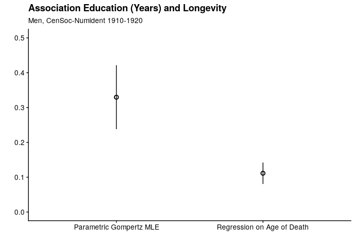

```r
## run linear model
lm_bpl <- lm(death_age ~ educ_yrs + as.factor(byear), data = data_numident_men, weights = weight)

## extract coefficients from model
lm_bpl_tidy <- tidy(lm_bpl) %>%
  filter(str_detect(term, "educ_yrs"))

## rename variables
ols_results <- lm_bpl_tidy %>%
  mutate(
    e65 = estimate,
    e65_lower = estimate - 1.96 * std.error,
    e65_upper = estimate + 1.96 * std.error
  ) %>%
  rename(parameter = term) %>%
  mutate(method = "Regression on Age of Death")

## Plot results
education_plot <- ols_results %>%
  bind_rows(mle_results_educ) %>%
  mutate(parameter = "Education (Years) Regression Coefficient") %>%
  ggplot(aes(x = method, y = e65, ymin = e65_lower, ymax = e65_upper)) +
  geom_pointrange(position = position_dodge(width = 0.2), shape = 1) +
  cowplot::theme_cowplot(font_size = 12) +
  theme(legend.position = "bottom", legend.title = element_blank()) +
  labs(
    x = "",
    title = "Association Education (Years) and Longevity",
    subtitle = "Men, CenSoc-Numident 1910-1920",
    y = ""
  ) +
  scale_color_brewer(palette = "Set1") +
  ylim(0, 0.5)

education_plot
```

## Summary and Limitations

The **gompertztrunc** package can be used to estimate mortality differentials without population denominators. A few limitations and considerations to this approach:

1. The Gompertz law does not apply perfectly to any application, and major departures from this assumption may bias estimates.
2. This approach assumes proportional hazards: i.e., the survival curves for different strata have hazard functions that are proportional over time.
3. The computational demands of this approach can be intensive, and the `gompertz_mle()` function runs into computational challenges when there are many parameters (e.g., models that have family fixed-effects).
4. The sample distribution of available deaths must be representative of the population distribution of deaths.